# Randomized Block Design

John Shorter

March/13/2024

# Introduction

We went over how to perform one-way ANOVA to compare means of multiple treatments. This time we’ll cover a common experimental design, that is randomized block design

we’ll go over

1. What are blocking factors,
2. Why they may be useful, and
3. How to analyze an experiment that has blocking factors

# Load packages

```r
#the same ones we used last time
library(emmeans)
library(multcomp)
```

```r
library(multcompView)
library(ggplot2)
library(tidyr)
library(dplyr)
library(readr)
library(readxl)
library(RColorBrewer)
library(viridis)
```

# Data

As an example, we’ll use the R built-in dataset OrchardSpray. This is an experiment with different spray treatments and compares their effect (the decrease of pests). Ref: McNeil, D. R. (1977) Interactive Data Analysis. New York: Wiley.

```r
head(OrchardSprays)
```

```
##   decrease rowpos colpos treatment
## 1       57      1      1         D
## 2       95      2      1         E
## 3        8      3      1         B
## 4       69      4      1         H
## 5       92      5      1         G
## 6       90      6      1         F
```

```r
str(OrchardSprays)
```

```
## 'data.frame':    64 obs. of  4 variables:
##  $ decrease : num  57 95 8 69 92 90 15 2 84 6 ...
##  $ rowpos   : num  1 2 3 4 5 6 7 8 1 2 ...
##  $ colpos   : num  1 1 1 1 1 1 1 1 2 2 ...
##  $ treatment: Factor w/ 8 levels "A","B","C","D",..: 4 5 2 8 7 6 3 1 3 2 ...
```

```r
#View(OrchardSprays) #Remember, it is possible to see the whole data set using View.
```

It has 64 rows. Looks like it has 8 treatments. The treatment is our independent variable. 64 rows / 8 treatment = 8 replicates per treatment.

“Decrease” will be our dependent variable.

So to set up a linear model for ANOVA, it would just be `lm(decrease ~ treatment)`.

However, there are two other columns: “rowpos” and “colpos”. They stand for row position and column position. These are blocking factors. So what exactly are they?

# What is a blocking factor?

The best way to understand them is to plot out the experimental design in ggplot.

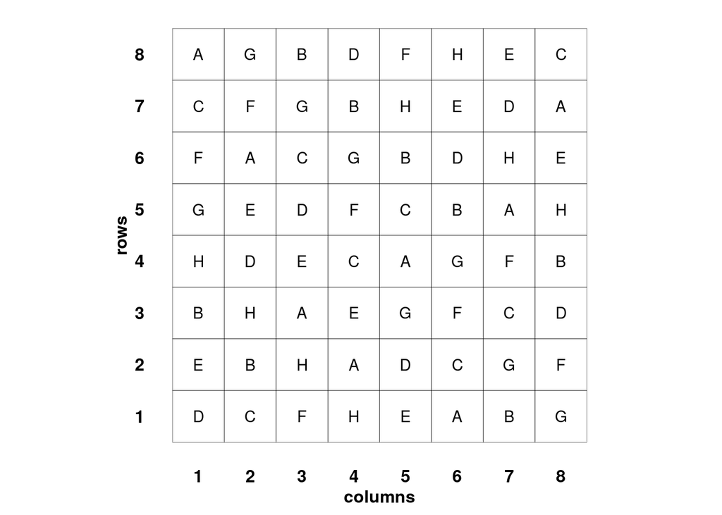

```r
OrchardSprays %>%
  ggplot(aes(x = colpos, y = rowpos)) +
  geom_tile(color = "black", fill = NA) +
  geom_text(aes(label = treatment)) +
  scale_x_continuous(breaks = c(1, 2, 3, 4, 5, 6, 7, 8)) +
  scale_y_continuous(breaks = c(1, 2, 3, 4, 5, 6, 7, 8)) +
  labs(x = "columns",
      y = "rows") +
  theme_minimal() +
  theme(panel.grid = element_blank(),
        text = element_text(size = 12, color = "black", face = "bold"),
        axis.text = element_text(size = 12, color = "black", face = "bold")
        ) +
  coord_fixed()
```

This is the design of the experiment. It is a 8x8 field. Each spot received a spray treatment (one of A-H), and the treatments (A-H) were randomized across rows and columns. We call the rows and columns blocking factors, in the sense that each row is a block, and each column is a block.

In reality, blocking factors can be as simple as a test tube rack.

- rack 1 | a | b | b | a | a | b |
- rack 2 | a | b | b | a | a | b |

In this example, I have two racks; each rack has 6 test tubes of rice seedlings. Each rack has two treatments (a vs. b), and 3 replicates each. Each rack can be used as a blocking factor.

In reality, blocking factors can be people as well. Say two students, Albert and Chad, needed to weigh 500 apples. Albert weighed half of them, and Chad weighed the rest. In this example, the person (Albert vs. Chad) can be used as a blocking factor.

# Why should one use blocking factors in an experiment?

Blocking factors allow you to control for unintended variations.

Let’s use the 8x8 plot as an example. Say there is a river near the right hand side of the orchard (to the right of column 8). That means the right side of the orchard is wetter than the left side. So it make sense to have column as a blocking factor, which controls for variation from left to right.

And Let’s say the upper side (row 8) is north, and the lower side (row 1) is south. And say this experiment happened in the northern hemisphere. This means the south side of the orchard is getting more sun light than the north side. So it make sense to have rows as blocking factor as well, which controls for variation from top to bottom.

# How do I analyze an experiment with blocking factors?

In this experiment, we should do `lm(decrease ~ treatment)`, but what other things should I include in the model?

To start, fill out this table

| sources | factor | levels |
| --- | --- | --- |
| … | … | … |

Sources stands for sources of variation.  
factor stands for is it a blocking factor? Is it a treatment? Is it an observation? levels - how many discrete levels? Or it is continuous?

SO…

| sources | factor | levels |
| --- | --- | --- |
| row | block | 8 |
| col | block | 8 |
| treatment | treatment | 8 |
| spot | OU, EU | 64 |

Rows and columns are blocking factors, and each has 8. Treatment is the treatment, and there are 8 treatments. Each spot is also a source of variation.

In this example, each spot is a replicate.  
It is also the observational unit (OU). I.e., where the observations were made.  
It is also the experimental unit (EU). I.e., the treatments were applied to each spot.

In many experiments, the observational unit is the experimental unit. However, this is not always the case. We’ll talk more about this when we talk about repeated measures and split field experiments.

The rule is to include all sources of variation in the model, other than the observational units. Simply put, all factors other than OU.  
That makes `decrease ~ treatment + rowpos + colpos`

# Visualize the data

*WARNING*: the rowpos and colpos are recorded as numeric variables in the table (1 - 8). To use them as blocking factors, we need to change them into factors!

```r
OrchardSprays_new <- OrchardSprays %>%
  mutate(row.F = as.factor(rowpos)) %>%  #mutate makes new columns based on existing columns
  mutate(col.F = as.factor(colpos))
```

Before we do any analysis, it’s a good idea to look at the data first. Make the best plot you can for this dataset. You’ll put decrease on x axis and treatment on y axis. The plot does not have to include the info for rows and columns. Rows and columns are blocking factors here. The only role of blocking factors is to control for unintended variations. And we are not actually interested the differences between rows and columns.

Make your plot here:

OrchardSprays %>%  
ggplot(aes(x = … , y = …)) + #What should be on x and y axes?  
geom_point(aes(fill = … )) #In this case, it could be the same as the X axis…

# Stat

## Setting up the model and check assumptions

We can pull out the summary statistics first.

```r
OrchardSprays_new %>%
  group_by(treatment) %>%
  summarise(mean = mean(decrease),
            var = var(decrease),
            sd = sd(decrease),
            n = n())
```

```
## # A tibble: 8 × 5
##   treatment  mean   var    sd     n
##   <fct>     <dbl> <dbl> <dbl> <int>
## 1 A          4.62  10.3  3.20     8
## 2 B          7.62  10.8  3.29     8
## 3 C         25.2  597.  24.4      8
## 4 D         35    181.  13.4      8
## 5 E         63.1  724.  26.9      8
## 6 F         69    852   29.2      8
## 7 G         68.5  406.  20.1      8
## 8 H         90.2  587.  24.2      8
```

If you look at the variances, this is very not ideal. Treatments A and B have very low variance. Treatments E and F have larger variances. But it doesn’t look like there is a consistent trend on how variances change with means. I don’t think a log or logit transformation would be helpful.

(If you are interested, you can try log and logit transformation and compare the results) But for now we’ll go with the original scale.

```r
model_spray <- lm(decrease ~ treatment + row.F + col.F, data = OrchardSprays_new)
```

Technically, there is slight difference between Y ~ treatment + blocks and Y ~ blocks + treatment. But for simplicity, let’s ignore that for now.

Now let’s check the assumptions of ANOVA. First off, normality.

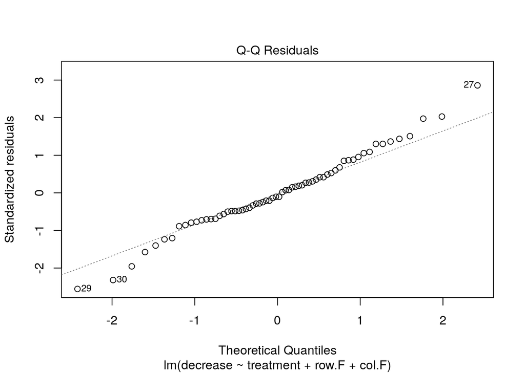

```r
plot(model_spray, which = 2)
```

That’s more or less ok.

Second, equal variance across groups

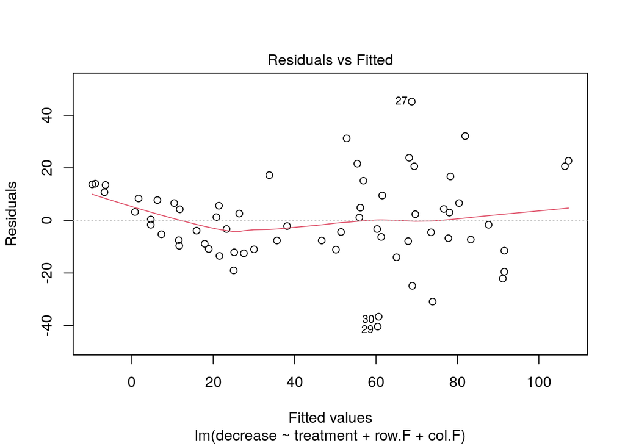

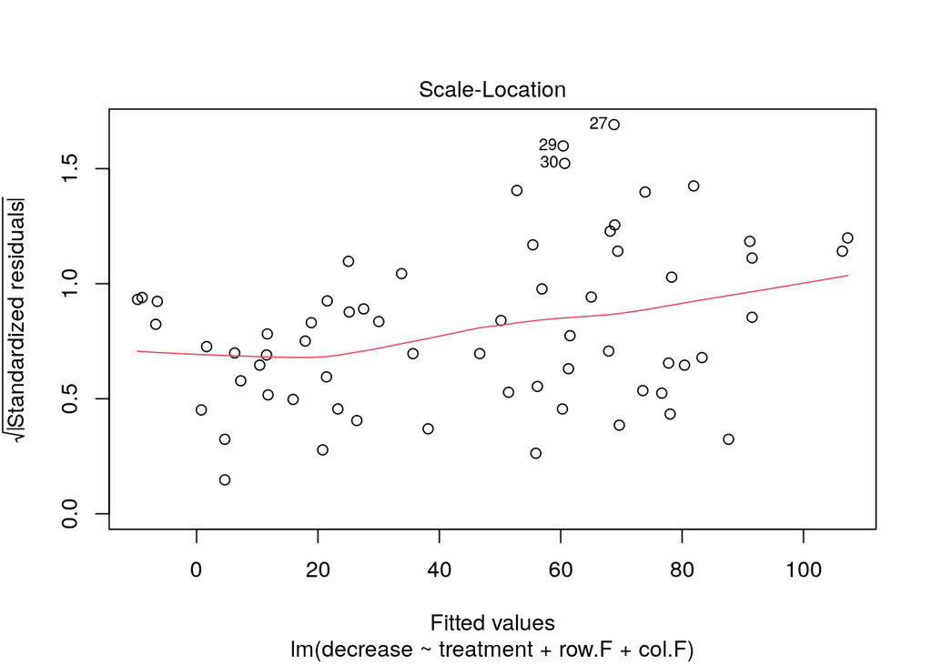

```r
plot(model_spray, which = c(1, 3))
```

It looks rather okay to me. There might be a few outliers around mean = 60 - 70. But that’s ok.

## ANOVA

```r
anova(model_spray)
```

```
## Analysis of Variance Table
##
## Response: decrease
##           Df Sum Sq Mean Sq F value    Pr(>F)
## treatment  7  56160  8022.9 21.0667 7.455e-12 ***
## row.F      7   4767   681.1  1.7884    0.1151
## col.F      7   2807   401.0  1.0530    0.4100
## Residuals 42  15995   380.8
## ---
## Signif. codes:  0 '***' 0.001 '**' 0.01 '*' 0.05 '.' 0.1 ' ' 1
```

## Tukey tests

Now we know there are differences among the means of different treatments. Let’s find out which treatment is the most effective (i.e highest decrease in pest) Again we’ll use the `emmeans` function. It will be the same thing of what we did last time.

```r
estimate_spray <- emmeans(model_spray, pairwise ~ treatment)
estimate_spray$contrasts
```

```
##  contrast estimate   SE df t.ratio p.value
##  A - B       -3.00 9.76 42  -0.307  1.0000
##  A - C      -20.62 9.76 42  -2.114  0.4231
##  A - D      -30.38 9.76 42  -3.113  0.0600
##  A - E      -58.50 9.76 42  -5.995  <.0001
##  A - F      -64.38 9.76 42  -6.598  <.0001
##  A - G      -63.88 9.76 42  -6.546  <.0001
##  A - H      -85.62 9.76 42  -8.775  <.0001
##  B - C      -17.62 9.76 42  -1.806  0.6194
##  B - D      -27.38 9.76 42  -2.806  0.1209
##  B - E      -55.50 9.76 42  -5.688  <.0001
##  B - F      -61.38 9.76 42  -6.290  <.0001
##  B - G      -60.88 9.76 42  -6.239  <.0001
##  B - H      -82.62 9.76 42  -8.468  <.0001
##  C - D       -9.75 9.76 42  -0.999  0.9720
##  C - E      -37.88 9.76 42  -3.882  0.0079
##  C - F      -43.75 9.76 42  -4.484  0.0013
##  C - G      -43.25 9.76 42  -4.433  0.0016
##  C - H      -65.00 9.76 42  -6.662  <.0001
##  D - E      -28.12 9.76 42  -2.882  0.1022
##  D - F      -34.00 9.76 42  -3.485  0.0235
##  D - G      -33.50 9.76 42  -3.433  0.0269
##  D - H      -55.25 9.76 42  -5.662  <.0001
##  E - F       -5.88 9.76 42  -0.602  0.9987
##  E - G       -5.38 9.76 42  -0.551  0.9992
##  E - H      -27.12 9.76 42  -2.780  0.1277
##  F - G        0.50 9.76 42   0.051  1.0000
##  F - H      -21.25 9.76 42  -2.178  0.3852
##  G - H      -21.75 9.76 42  -2.229  0.3560
##
## Results are averaged over the levels of: row.F, col.F
## P value adjustment: tukey method for comparing a family of 8 estimates
```

I just pulled out all the pairwise contrasts. Keep in mind that because we included rows and columns in the model, the means of each treatment is first averaged across rows and columns. So the variation due to rows and columns are already accounted for. Yay. You can see the “Results are averaged over the levels of: row.F, col.F” message.

Because we have 8 treatments, so we have 8 choose 2 = 28 different comparisons. This is a bit too much to look at. To save space, let’s pull out the cld (compact letter display).

```r
cld(estimate_spray$emmeans, Letters = letters)
```

```
##  treatment emmean  SE df lower.CL upper.CL .group
##  A           4.62 6.9 42     -9.3     18.5  a
##  B           7.62 6.9 42     -6.3     21.5  a
##  C          25.25 6.9 42     11.3     39.2  a
##  D          35.00 6.9 42     21.1     48.9  ab
##  E          63.12 6.9 42     49.2     77.0   bc
##  G          68.50 6.9 42     54.6     82.4    c
##  F          69.00 6.9 42     55.1     82.9    c
##  H          90.25 6.9 42     76.3    104.2    c
##
## Results are averaged over the levels of: row.F, col.F
## Confidence level used: 0.95
## P value adjustment: tukey method for comparing a family of 8 estimates
## significance level used: alpha = 0.05
## NOTE: If two or more means share the same grouping symbol,
##       then we cannot show them to be different.
##       But we also did not show them to be the same.
```

What does this mean?

It means

1. the means of treatments ABCD are not significantly different from each other, because they all share the letter “a”.
2. the means of treatments DE are not significantly different from each other, because they both share the letter “b”.
3. the means of treatments EGFH are not significantly different from each other, because they all share the letter “c”.

From this we can conclude that treatment GFH are the most effective treatments by Tukey tests. Note that treatment H is numerically the highest, but it is not detected as significantly different from treatments F,G and E. How to reconcile that? There are two ways

1. The numerically greatest mean is due to pure chance. And if you were to perform the experiment again, the mean of H may be lower next time.
2. The mean of H is actually higher than the rest, but this experiment does not have enough power to detect that. If you were to re-run the experiment with more reps (say 16 instead of 8), you might detect a significant difference between H and the rest next time.

Based on the means, H is ~20 higher than the next highest (F and G). It’s likely that interpretation 2) is correct.

Note that although A shares the letter “a” with B, and H shares the letter “c” with F, *IN NO WAY* this proves mean(a) = mean(b), or mean(H) = mean(F).

Again, when you interpret P values and the letter grouping, be thoughtful and careful on what they could mean, and what they don’t mean.

# Exercise

Now you have learned how to analyze randomized block experiments. Let’s practice that!

This time we will look at an actual experiment

```r
chicken_experiment <- read_csv("/work/Data/Rmodule_data/betacarotenoid.csv")
head(chicken_experiment)
```

```
## # A tibble: 6 × 3
##   Field Pasture  Beta
##   <chr> <chr>   <dbl>
## 1 F1    P1       3.63
## 2 F1    P2       3.49
## 3 F1    P3       3.84
## 4 F1    P4       4.6
## 5 F1    P5       5.32
## 6 F2    P1       3.81
```

The researcher was testing the effect of different pastures (P1 to P5). on the amount of beta-carotene in egg. There were 4 fields (F1 - F4). The fields are the blocking factors. In each field, hens were randomly assigned to be fed with one of the 5 pastures. At the end of the experiment, eggs were collected and beta-carotene concentration was assayed. (Data from UC Davis Plant Sciences course PLS205, Winter 2017)

## Visualize the data

make the best plot you can to visualize the data.

What to put on x axis? What to color/fill with? You don’t have to include blocking factors in the plot

## Setting up the model

Fill out the table:

What are the sources of variation? What factors are they? (treatment? block? observational units? experimental units?) How many levels in each?

| source | factor | levels |
| --- | --- | --- |
| … | … | … |

What should you include in the model? Set up the linear model.

## Check assumptions of ANOVA

Normality?

Equal variance?

## Run ANOVA

How would you interpret the ANOVA table?

## Run Tukey tests and show cld

Which pasture treatment gave the best beta-carotene content?